# 4. Custom Fitting: MuSyC Synergy

gDR team

2026-11-23

4. Custom Fitting: MuSyC Synergy

**gDR Analysis Pipeline**

Date: 2026-11-23

Author: [gDR team](https://github.com/gdrplatform)

# 1 Introduction

The gDR pipeline scores combinations with Bliss, HSA and the Loewe-based combination index (Step 3). This report shows how a **different model** is added on top of the same processed data without changing the pipeline: a *fit function* is passed to `gDRutils::apply_fit()`, which calls it once per drug pair, cell line and normalization type, and stores the results as a new assay next to the native ones.

The model here is **MuSyC** (multi-dimensional synergy of combinations, Meyer et al., *Cell Systems* 2019). It fits a dose-response surface to the whole combination grid and separates two kinds of synergy:

- **synergy of potency**, `alpha12` and `alpha21`: one drug shifts the potency of the other (`alpha > 1` synergistic, `alpha < 1` antagonistic);
- **synergy of efficacy**, `beta`: the combination reaches a deeper maximal effect than the stronger drug alone (`beta > 0` synergistic).

The fit function, `gDRcore::musyc_fit_fn()`, runs the fit in R. It needs gDRcore 1.11.33 or later, which is not on Bioconductor yet: install gDRutils and gDRcore from GitHub with `remotes::install_github(c("gdrplatform/gDRutils", "gdrplatform/gDRcore"))`.

```r
library(qs2)
library(SummarizedExperiment)
library(data.table)
library(writexl)
library(gDRutils)
library(gDRcore)
library(gDRplots)
library(ggplot2)
```

```r
if (packageVersion("gDRcore") < "1.11.33") {
  stop("This report needs gDRcore 1.11.33 or later: ",
       "remotes::install_github(c(\"gdrplatform/gDRutils\", \"gdrplatform/gDRcore\"))")
}
```

# 2 Read the gDR MAE data

This report starts from the `MultiAssayExperiment` saved by Step 2 and uses its combination experiment.

```r
wd <- getwd()
dir.create(file.path(wd, "tables"), showWarnings = FALSE, recursive = TRUE)
mae <- qs_read(file.path(wd, "gDR_data", "gDR_mae.qs2"))
combo_se <- mae[[get_supported_experiments("combo")]]
assayNames(combo_se)
```

```
## [1] "RawTreated"     "Controls"       "Normalized"     "Averaged"
## [5] "Metrics"        "excess"         "isobolograms"   "all_iso_points"
## [9] "scores"
```

# 3 The fit function contract

A fit function receives the `Averaged` responses of one cell — one drug pair, one cell line, one normalization type — as a `data.table` with the two concentrations and the response `x`, and returns a named list. Every element becomes a column of the output assay.

```r
cell_line_col <- get_env_identifiers("cellline_name")
drug_col <- get_env_identifiers("drug_name")
drug2_col <- get_env_identifiers("drug_name2")
id_cols <- c(cell_line_col, drug_col, drug2_col, "normalization_type")

avg_dt <- convert_se_assay_to_dt(combo_se, "Averaged")
one_cell <- avg_dt[avg_dt[[cell_line_col]] == avg_dt[[cell_line_col]][1] &
                     avg_dt[[drug_col]] == avg_dt[[drug_col]][1] &
                     normalization_type == "GR"]
head(one_cell[, c("Concentration", "Concentration_2", "x")])
```

```
##    Concentration Concentration_2       x
##            <num>           <num>   <num>
## 1:             0     0.000762079 0.96055
## 2:             0     0.002286236 0.96500
## 3:             0     0.006858703 0.81505
## 4:             0     0.020576144 0.55885
## 5:             0     0.061728397 0.41610
## 6:             0     0.185185083 0.39665
```

```r
str(musyc_fit_fn(one_cell))
```

```
## List of 14
##  $ normalization_type: chr "GR"
##  $ E0                : num 0.993
##  $ E1                : num 0.45
##  $ E2                : num 0.282
##  $ E3                : num 0.268
##  $ h1                : num 21.8
##  $ h2                : num 1.05
##  $ C1                : num 0.122
##  $ C2                : num 0.0164
##  $ alpha12           : num 1.5
##  $ alpha21           : num 2.88
##  $ beta              : num 0.0186
##  $ r2                : num 0.961
##  $ converged         : logi TRUE
```

# 4 Fit MuSyC to every cell

`apply_fit()` runs the fit function over the whole SE. `musyc_summary_fn()` then collapses the fits of the two normalization types into one row per cell. Both results land next to the native assays; nothing that was there is changed.

```r
combo_se <- apply_fit(
  combo_se,
  fit_fn = musyc_fit_fn,
  data_type = "combination",
  output_assay = "musyc_params",
  summary_fn = musyc_summary_fn,
  summary_assay = "musyc_summary",
  fit_source = "musyc"
)
assayNames(combo_se)
```

```
##  [1] "RawTreated"     "Controls"       "Normalized"     "Averaged"
##  [5] "Metrics"        "excess"         "isobolograms"   "all_iso_points"
##  [9] "scores"         "musyc_params"   "musyc_summary"
```

```r
musyc_params <- convert_se_assay_to_dt(combo_se, "musyc_params")
musyc_summary <- convert_se_assay_to_dt(combo_se, "musyc_summary")
clip_log2 <- function(v) pmin(pmax(log2(v), -10), 10)
musyc_params[, `:=`(log2_alpha12 = clip_log2(alpha12), log2_alpha21 = clip_log2(alpha21))]
musyc_params[, log2_alpha := (log2_alpha12 + log2_alpha21) / 2]
param_cols <- c("E1", "E2", "E3", "h1", "h2", "C1", "C2", "alpha12", "alpha21", "log2_alpha", "beta", "r2", "converged")
generate_datatable(musyc_params[, c(id_cols, param_cols), with = FALSE][
  , lapply(.SD, function(v) if (is.numeric(v)) signif(v, 3) else v)])
```

|  | CellLineName | DrugName | DrugName_2 | normalization_type | E1 | E2 | E3 | h1 | h2 | C1 | C2 | alpha12 | alpha21 | log2_alpha | beta | r2 | converged |
| --- | --- | --- | --- | --- | --- | --- | --- | --- | --- | --- | --- | --- | --- | --- | --- | --- | --- |
| 1 | A-375 | Belvarafenib | Cobimetinib | GR | 0.45 | 0.282 | 0.268 | 21.8 | 1.05 | 0.122 | 0.0164 | 1.5 | 2.88 | 1.06 | 0.0186 | 0.961 | True |
| 2 | A-375 | Belvarafenib | Cobimetinib | RV | 0.256 | 0.125 | 0.125 | 2.81 | 1.39 | 0.0945 | 0.00839 | 7.01 | 0.718 | 1.17 | -0.000548 | 0.978 | True |
| 3 | A-375 | Vemurafenib | Cobimetinib | GR | 0.319 | 0.313 | 0.215 | 1.17 | 1.21 | 0.375 | 0.0153 | 4.11 | 0.0939 | -0.688 | 0.14 | 0.973 | True |
| 4 | A-375 | Vemurafenib | Cobimetinib | RV | 0.157 | 0.142 | 0.125 | 1.86 | 1.51 | 0.231 | 0.00922 | 2.34 | 2.44 | 1.26 | 0.02 | 0.985 | True |
| 5 | A-431 | Belvarafenib | Cobimetinib | GR | 0.859 | 0.203 | 0.0465 | 1.75 | 1.37 | 0.39 | 0.364 | 12.6 | 10.1 | 3.49 | 0.198 | 0.985 | True |
| 6 | A-431 | Belvarafenib | Cobimetinib | RV | 0.744 | 0.125 | 0.0542 | 1.8 | 1.15 | 0.337 | 0.18 | 8.7 | 7.81 | 3.04 | 0.0824 | 0.985 | True |
| 7 | A-431 | Vemurafenib | Cobimetinib | GR | 0.998 | -0.0501 | -0.256 | 114 | 0.726 | 7.74 | 0.857 | 6.36 | 2.31 | 1.94 | 0.195 | 0.985 | True |
| 8 | A-431 | Vemurafenib | Cobimetinib | RV | 1.5 | 0.0185 | 0.0392 | 3.63 | 0.765 | 10000 | 0.268 | 528 | 1950 | 9.52 | -0.0209 | 0.98 | True |
| 9 | A2058 | Belvarafenib | Cobimetinib | GR | 0.863 | 0.699 | 0.667 | 21.3 | 1.23 | 0.125 | 0.0602 | 3.1 | 8.99 | 2.4 | 0.107 | 0.937 | True |
| 10 | A2058 | Belvarafenib | Cobimetinib | RV | 0.62 | 0.346 | 0.302 | 2.98 | 1.4 | 0.123 | 0.0374 | 2.46 | 4.93 | 1.8 | 0.0682 | 0.948 | True |

[output cut: 30 more lines]

Drug 1 is `DrugName` and drug 2 is `DrugName_2`. `alpha12` is how drug 1 shifts the potency of drug 2 and `alpha21` the reverse. `log2_alpha12` and `log2_alpha21` are clipped to [-10, 10], as in `musyc_summary_fn()`, and `log2_alpha` is their mean. 40 of 40 fits converged, with a median R² of 0.979. A fit that does not converge has `NA` parameters and is left out below.

# 5 Potency and efficacy synergy

Each point is one cell line and drug pair. Points to the right show synergy of potency, points above zero synergy of efficacy.

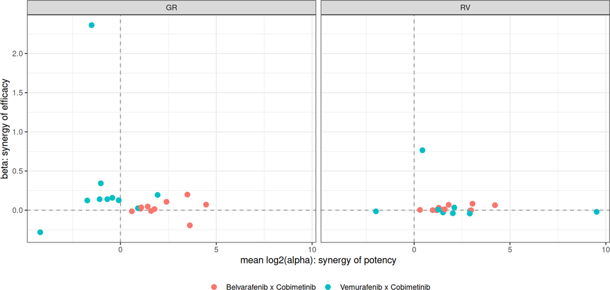

```r
musyc_converged <- musyc_params[converged %in% TRUE]
musyc_converged[, pair := paste(get(drug_col), "x", get(drug2_col))]
ggplot(musyc_converged, aes(log2_alpha, beta, colour = pair)) +
  geom_hline(yintercept = 0, linetype = "dashed", colour = "grey60") +
  geom_vline(xintercept = 0, linetype = "dashed", colour = "grey60") +
  geom_point(size = 2.5) +
  facet_wrap(~normalization_type) +
  labs(x = "mean log2(alpha): synergy of potency", y = "beta: synergy of efficacy", colour = NULL) +
  theme_bw() +
  theme(legend.position = "bottom")
```

`alpha` is estimated well only when the surface constrains it. Where the combination barely moves the response, very different `alpha` values fit the data equally well.

`beta` is `(min(E1, E2) - E3) / (E0 - min(E1, E2))`, so it gets large when the stronger drug alone has little effect. A large `beta` next to a strongly negative `log2(alpha)` is usually the fit trading potency against efficacy. Read both together with the dose-response surface and `r2`, not on their own.

# 6 Synergy call for each normalization type

`apply_fit()` gives `musyc_summary_fn()` the fits of both normalization types at once, so `musyc_summary` holds one call per cell. GR and RV can disagree, so here the same function runs on each type separately.

```r
musyc_summary_by_norm <- musyc_params[, musyc_summary_fn(.SD), by = id_cols]
dcast(musyc_summary_by_norm, synergy_call ~ normalization_type, fun.aggregate = length, value.var = "synergy_call")
```

```
## Key: <synergy_call>
##    synergy_call    GR    RV
##          <char> <int> <int>
## 1:     additive     8    19
## 2: antagonistic     2     0
## 3:  synergistic    10     1
```

```r
generate_datatable(musyc_summary_by_norm[, lapply(.SD, function(v) if (is.numeric(v)) signif(v, 3) else v)])
```

|  | CellLineName | DrugName | DrugName_2 | normalization_type | mean_beta | mean_log2_alpha | mean_r2 | any_converged | synergy_call |
| --- | --- | --- | --- | --- | --- | --- | --- | --- | --- |
| 1 | A-375 | Belvarafenib | Cobimetinib | GR | 0.0186 | 1.06 | 0.961 | True | additive |
| 2 | A-375 | Belvarafenib | Cobimetinib | RV | -0.000548 | 1.17 | 0.978 | True | additive |
| 3 | A-375 | Vemurafenib | Cobimetinib | GR | 0.14 | -0.688 | 0.973 | True | synergistic |
| 4 | A-375 | Vemurafenib | Cobimetinib | RV | 0.02 | 1.26 | 0.985 | True | additive |
| 5 | A-431 | Belvarafenib | Cobimetinib | GR | 0.198 | 3.49 | 0.985 | True | synergistic |
| 6 | A-431 | Belvarafenib | Cobimetinib | RV | 0.0824 | 3.04 | 0.985 | True | additive |
| 7 | A-431 | Vemurafenib | Cobimetinib | GR | 0.195 | 1.94 | 0.985 | True | synergistic |
| 8 | A-431 | Vemurafenib | Cobimetinib | RV | -0.0209 | 9.52 | 0.98 | True | additive |
| 9 | A2058 | Belvarafenib | Cobimetinib | GR | 0.107 | 2.4 | 0.937 | True | synergistic |
| 10 | A2058 | Belvarafenib | Cobimetinib | RV | 0.0682 | 1.8 | 0.948 | True | additive |

[output cut: 30 more lines]

# 7 MuSyC next to Bliss

The native `scores` assay holds the Bliss score of Step 3: the mean of the top 10% of the excess over the Bliss independence expectation on the dose grid. It is above zero in almost every combination, synergistic or not, so it ranks combinations rather than calling them. MuSyC splits the excess into potency and efficacy.

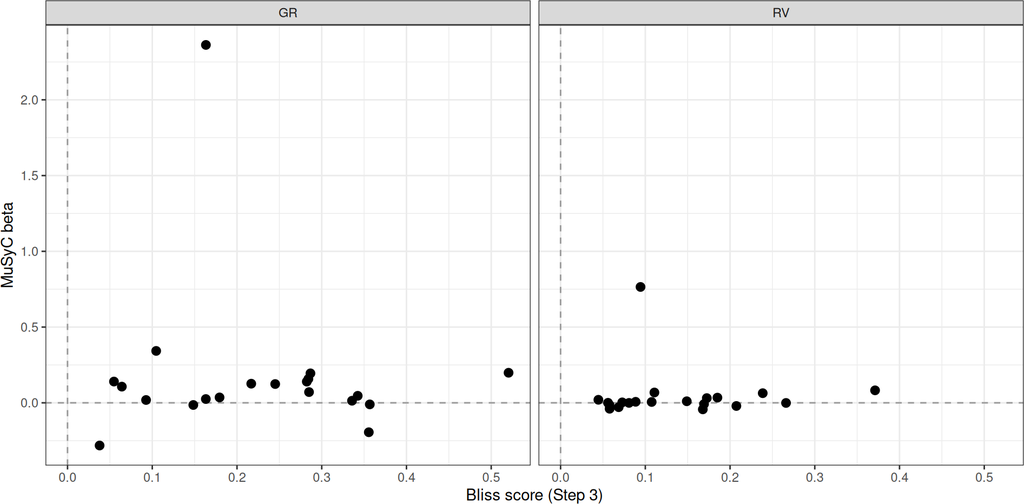

```r
scores <- convert_se_assay_to_dt(combo_se, "scores")
compare <- merge(
  musyc_converged[, c(id_cols, "log2_alpha", "beta"), with = FALSE],
  scores[, c(id_cols, "bliss_score"), with = FALSE],
  by = id_cols
)
ggplot(compare, aes(bliss_score, beta)) +
  geom_hline(yintercept = 0, linetype = "dashed", colour = "grey60") +
  geom_vline(xintercept = 0, linetype = "dashed", colour = "grey60") +
  geom_point(size = 2.5) +
  facet_wrap(~normalization_type) +
  labs(x = "Bliss score (Step 3)", y = "MuSyC beta") +
  theme_bw()
```

`beta` above 0.1 is outside the dead zone of `musyc_summary_fn()`; `log2(alpha)` above 1 is at least a two-fold shift in potency. The counts include the fits that trade potency against efficacy.

- **Relative Viability:** of the 20 converged fits, `beta` exceeds 0.1 in 1 and `log2(alpha)` exceeds 1 in 16. The synergy comes mostly through **potency** — each drug makes the other work at lower doses — rather than through a deeper maximal effect.
- **GR Value:** of the 20 converged fits, `beta` exceeds 0.1 in 10 and `log2(alpha)` exceeds 1 in 10. The synergy comes through both **potency** and **efficacy**, neither twice as often as the other.

A single score such as Bliss cannot tell these apart.

# 8 MuSyC parameters in the layout of Step 3

Step 3 reads single-agent results as heatmaps of drug by cell line and combinations as heatmaps of drug pair by cell line. The MuSyC parameters split along the same line, so they are drawn in the same two layouts rather than as one heatmap: they have different units and each needs its own scale.

- `E1`, `E2` (effect at saturation, like `x_inf`), `C1`, `C2` (half-maximal concentration, like `ec50`) and `h1`, `h2` (Hill slope) describe one drug each and are drawn like the single-agent metrics.
- `E3` is the effect of the combination at saturation. It is drawn next to `E1` and `E2`, because `beta` compares it with the stronger drug.
- `alpha12`, `alpha21` and `beta` describe the pair and are drawn like the Bliss and HSA scores.
- `r2` stays in the table above, as the R² of the single-agent fits stays in the `Metrics` table of Step 3.

The plots share the gDRplots functions of Step 3, so the clustering, annotation and colour scales match.

```r
tissue_col <- get_env_identifiers("cellline_tissue")
moa_col <- get_env_identifiers("drug_moa")
moa2_col <- get_env_identifiers("drug_moa2")
norm_names <- c(RV = "Relative Viability", GR = "GR Value")

draw_heatmap <- function(hm) {
  grid::grid.newpage()
  grid::grid.draw(hm$heatmap$gtable)
}
plot_tabs <- function(plots, level, draw = print) {
  for (nm in names(plots)) {
    cat("\n\n", strrep("#", level), " ", nm, "\n\n", sep = "")
    draw(plots[[nm]])
  }
}
annotation_col <- unique(musyc_params[, c(cell_line_col, tissue_col), with = FALSE])
```

## 8.1 Synergy parameters

### 8.1.1 Heatmaps

Each heatmap shows one synergy parameter for every drug pair (rows) and cell line (columns), on a scale symmetric around zero: red is synergy, blue antagonism.

```r
synergy_metrics <- c(log2_alpha12 = "log2(alpha12)", log2_alpha21 = "log2(alpha21)",
                     log2_alpha = "mean log2(alpha)", beta = "beta")
annotation_row <- unique(musyc_params[, c(drug_col, drug2_col, moa_col, moa2_col), with = FALSE])
annotation_map <- get_ann_color_map(unique(musyc_params[, c(tissue_col, moa_col, moa2_col), with = FALSE]))
for (norm in names(norm_names)) {
  cat("\n\n#### ", norm_names[[norm]], " {.tabset}\n\n", sep = "")
  plots <- lapply(names(synergy_metrics), function(metric) {
    pheatmap_with_anno_combo(musyc_params, normalization_type = norm, metric = metric, fit_source = "musyc",
                             hm_title = sprintf("MuSyC %s, %s", synergy_metrics[[metric]], norm),
                             annotation_row = annotation_row, annotation_col = annotation_col,
                             annotation_colors = annotation_map)
  })
  names(plots) <- synergy_metrics
  plot_tabs(plots, level = 5, draw = draw_heatmap)
}
```

#### 8.1.1.1 Relative Viability

##### 8.1.1.1.1 log2(alpha12)

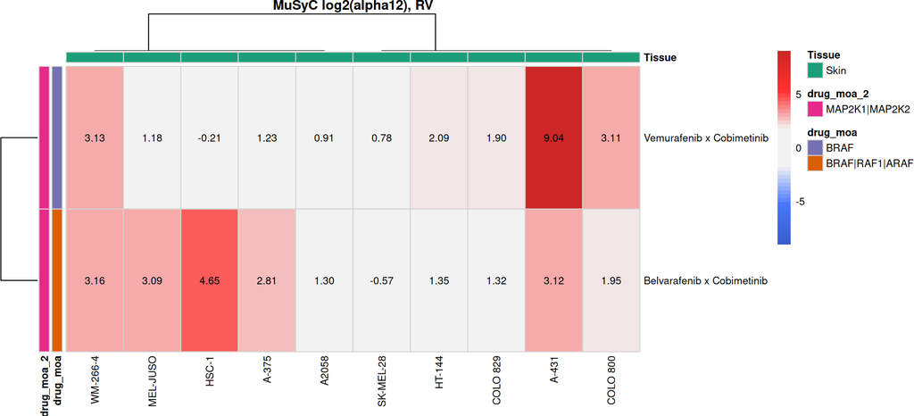

##### 8.1.1.1.2 log2(alpha21)

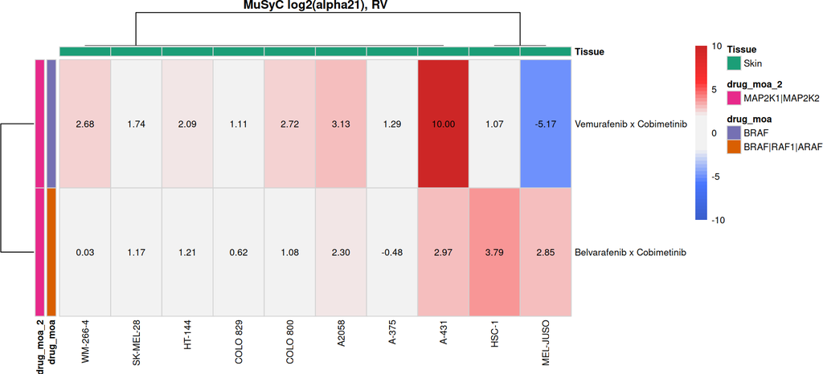

##### 8.1.1.1.3 mean log2(alpha)

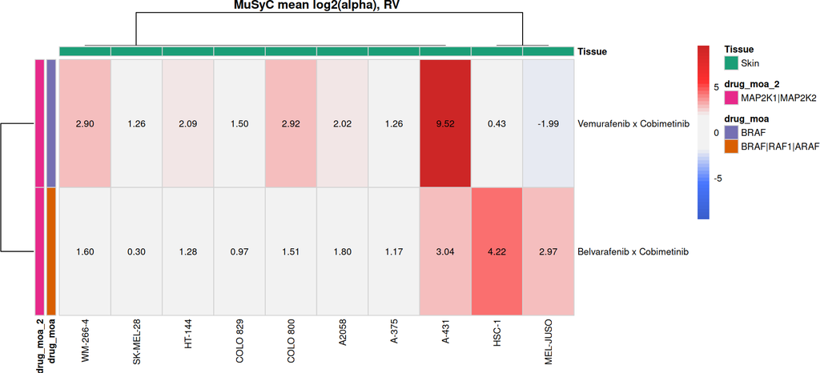

##### 8.1.1.1.4 beta

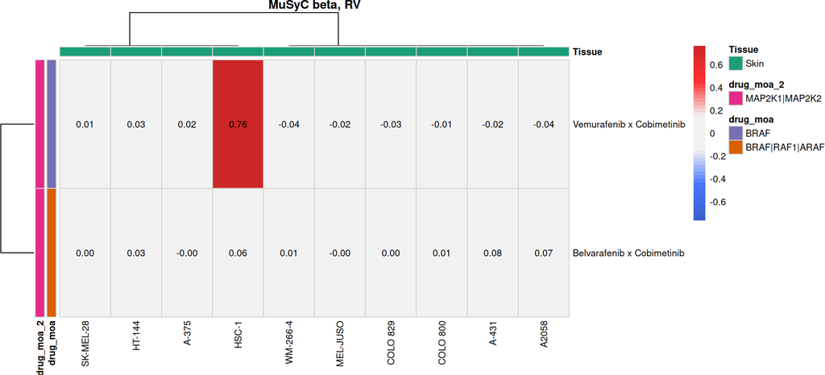

#### 8.1.1.2 GR Value

##### 8.1.1.2.1 log2(alpha12)

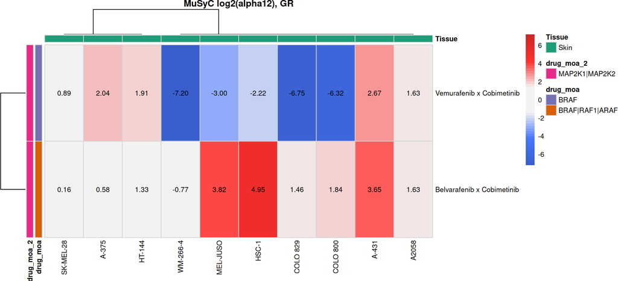

##### 8.1.1.2.2 log2(alpha21)

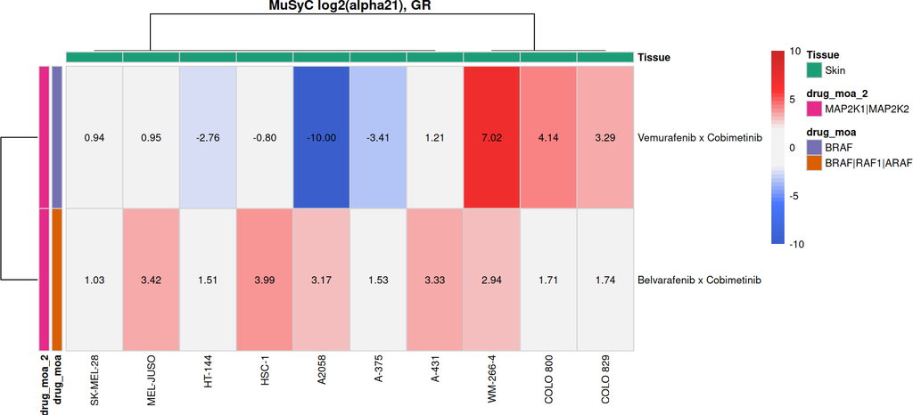

##### 8.1.1.2.3 mean log2(alpha)

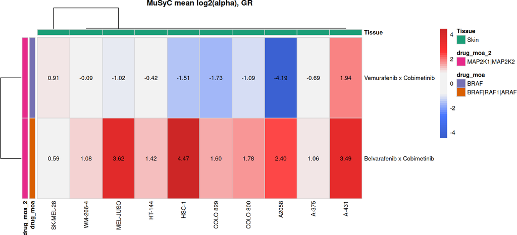

##### 8.1.1.2.4 beta

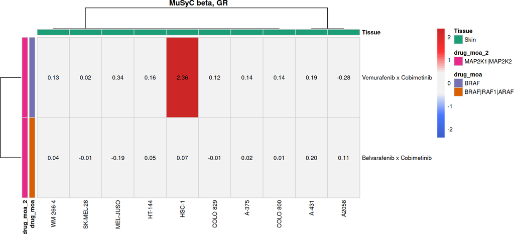

### 8.1.2 Boxplots by Cell Lines

```r
box_metrics <- synergy_metrics[c("log2_alpha", "beta")]
for (norm in names(norm_names)) {
  cat("\n\n#### ", norm_names[[norm]], " {.tabset}\n\n", sep = "")
  plots <- lapply(names(box_metrics), function(metric) {
    plot_boxplot_metric_combo_by_CLs(musyc_params, normalization_type = norm, metric = metric,
                                     fit_source = "musyc", colored_pts_flag = TRUE)
  })
  names(plots) <- box_metrics
  plot_tabs(plots, level = 5)
}
```

#### 8.1.2.1 Relative Viability

##### 8.1.2.1.1 mean log2(alpha)

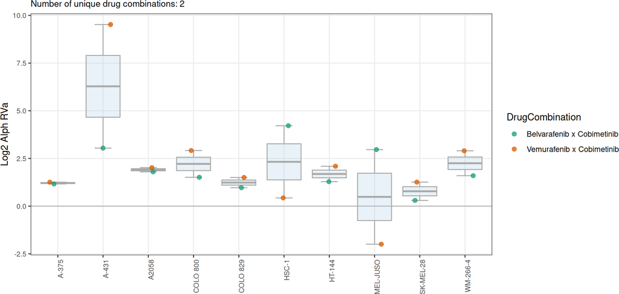

##### 8.1.2.1.2 beta

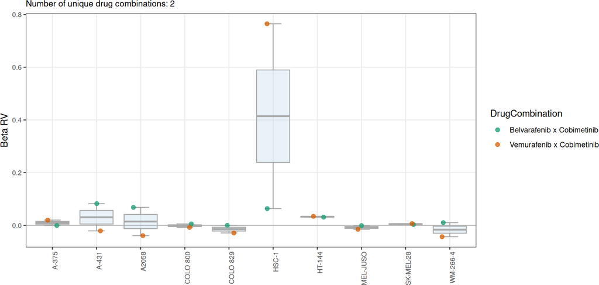

#### 8.1.2.2 GR Value

##### 8.1.2.2.1 mean log2(alpha)

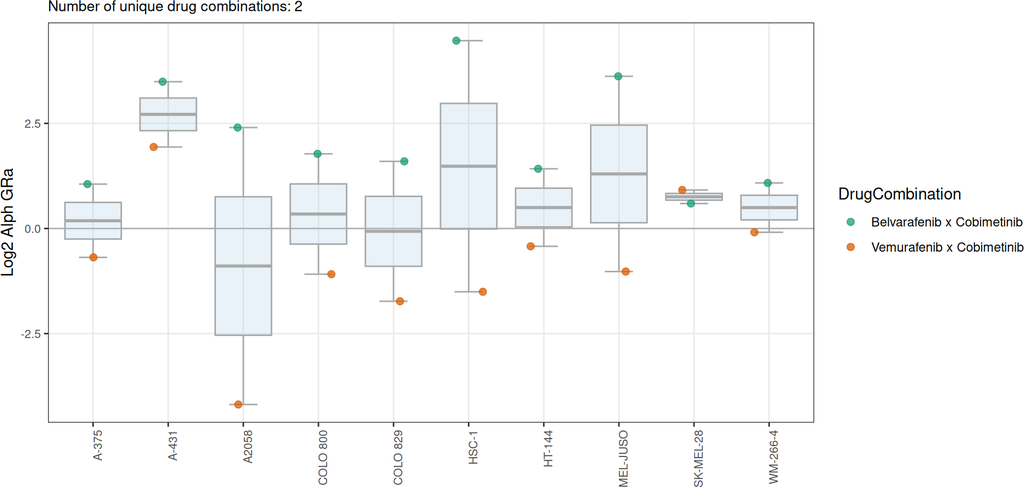

##### 8.1.2.2.2 beta

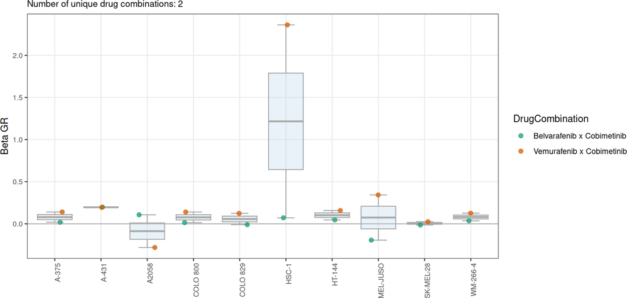

### 8.1.3 Boxplots by Drugs

```r
for (norm in names(norm_names)) {
  cat("\n\n#### ", norm_names[[norm]], " {.tabset}\n\n", sep = "")
  plots <- lapply(names(box_metrics), function(metric) {
    plot_boxplot_metric_combo_by_drugs(musyc_params, normalization_type = norm, metric = metric,
                                       fit_source = "musyc", colored_pts_flag = TRUE)
  })
  names(plots) <- box_metrics
  plot_tabs(plots, level = 5)
}
```

#### 8.1.3.1 Relative Viability

##### 8.1.3.1.1 mean log2(alpha)

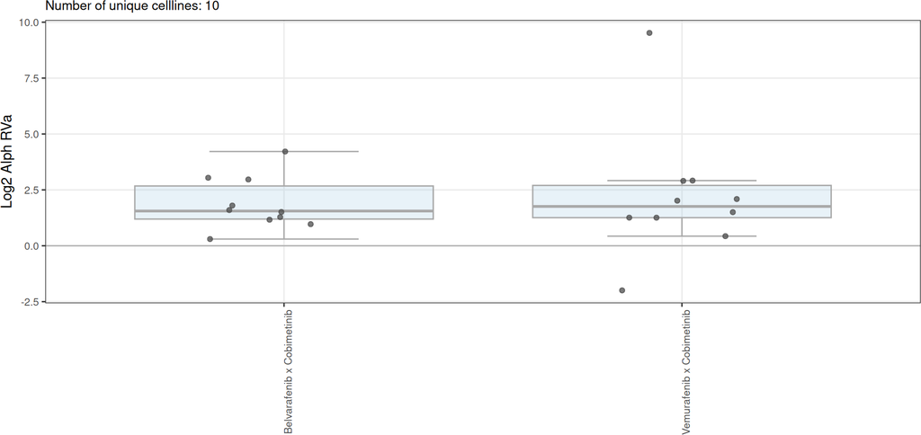

##### 8.1.3.1.2 beta

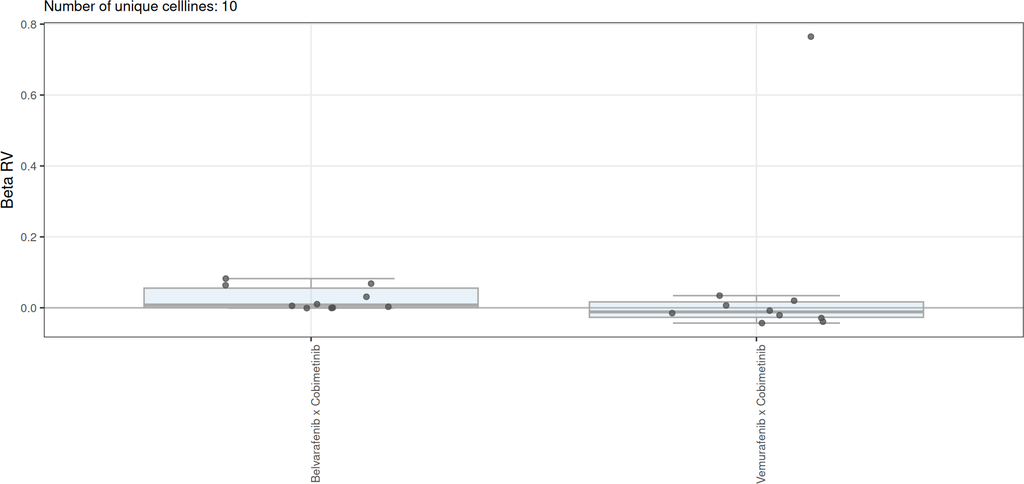

#### 8.1.3.2 GR Value

##### 8.1.3.2.1 mean log2(alpha)

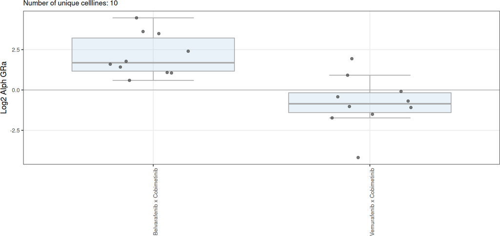

##### 8.1.3.2.2 beta

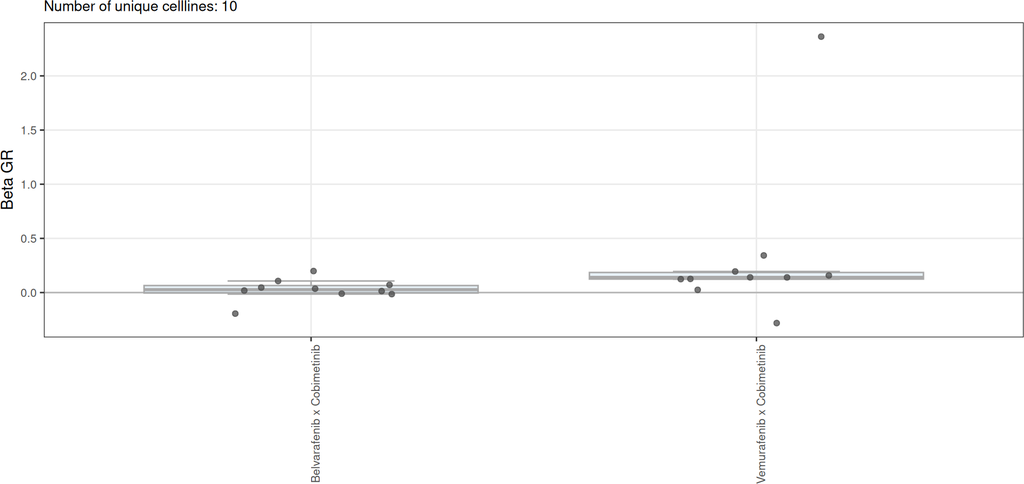

All cell lines in these data come from one tissue (Skin), so the boxplots by tissue of Step 3 are left out.

## 8.2 Single-drug parameters

### 8.2.1 Heatmaps

Each row is one drug as fitted inside one pair, labelled with its partner: a drug tested in several pairs gets one row per pair. MuSyC fits the single drugs together with the synergy, so these rows are independent estimates of the same drug and should agree. Where they do not, the single-drug parameters traded off against `alpha` in the fit, and `alpha` for that cell line deserves less weight. The rows labelled `A + B` carry `E3`, the effect of the combination at saturation, on the scale of `E1` and `E2`.

```r
single_drug_rows <- function(dt, drug, partner, E, C, h) {
  out <- dt[, c(cell_line_col, tissue_col, "normalization_type", "fit_source", "converged"), with = FALSE]
  out[, `:=`(label = sprintf("%s (with %s)", dt[[drug]], dt[[partner]]),
             drug = dt[[drug]], partner = dt[[partner]],
             E = dt[[E]], log10_C = log10(dt[[C]]), h = dt[[h]])]
  out
}
combination_rows <- musyc_params[, c(cell_line_col, tissue_col, "normalization_type", "fit_source", "converged"),
                                 with = FALSE]
combination_rows[, `:=`(label = sprintf("%s + %s", musyc_params[[drug_col]], musyc_params[[drug2_col]]),
                        drug = "combination", partner = "combination",
                        E = musyc_params$E3, log10_C = NA_real_, h = NA_real_)]
musyc_drugs <- rbind(
  single_drug_rows(musyc_params, drug_col, drug2_col, "E1", "C1", "h1"),
  single_drug_rows(musyc_params, drug2_col, drug_col, "E2", "C2", "h2"),
  combination_rows
)
musyc_drugs[!converged %in% TRUE, c("E", "log10_C", "h") := NA_real_]
setnames(musyc_drugs, "label", drug_col)
```

```r
single_drug_metrics <- c(E = "E", log10_C = "log10(C)", h = "h")
annotation_row_sd <- unique(musyc_drugs[, c(drug_col, "drug", "partner"), with = FALSE])
tissues <- unique(annotation_col[[tissue_col]])
drugs <- unique(c(annotation_row_sd$drug, annotation_row_sd$partner))
sd_colors <- get_qual_colors(length(tissues) + length(drugs))
drug_colors <- stats::setNames(sd_colors[length(tissues) + seq_along(drugs)], drugs)
annotation_map_sd <- list(stats::setNames(sd_colors[seq_along(tissues)], tissues), drug_colors, drug_colors)
names(annotation_map_sd) <- c(tissue_col, "drug", "partner")
for (norm in names(norm_names)) {
  cat("\n\n#### ", norm_names[[norm]], " {.tabset}\n\n", sep = "")
  plots <- lapply(names(single_drug_metrics), function(metric) {
    dt <- musyc_drugs[!is.na(get(metric))]
    pheatmap_with_anno_sa(dt, normalization_type = norm, metric = metric, fit_source = "musyc",
                          hm_title = sprintf("MuSyC %s, %s", single_drug_metrics[[metric]], norm),
                          cluster_rows = FALSE,
                          annotation_row = annotation_row_sd[get(drug_col) %in% dt[[drug_col]]],
                          annotation_col = annotation_col, annotation_colors = annotation_map_sd)
  })
  names(plots) <- single_drug_metrics
  plot_tabs(plots, level = 5, draw = draw_heatmap)
}
```

#### 8.2.1.1 Relative Viability

##### 8.2.1.1.1 E

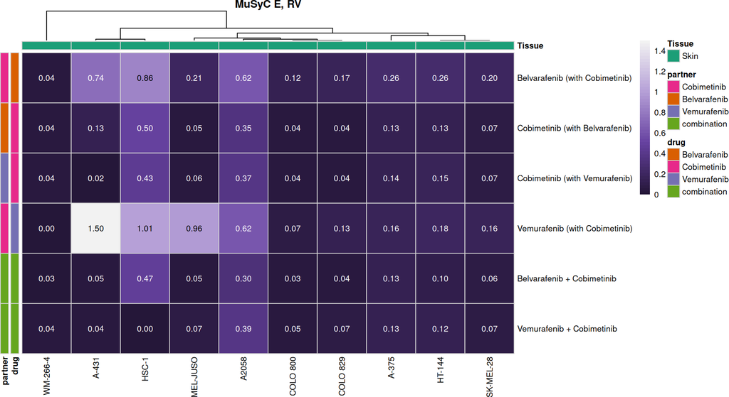

##### 8.2.1.1.2 log10(C)

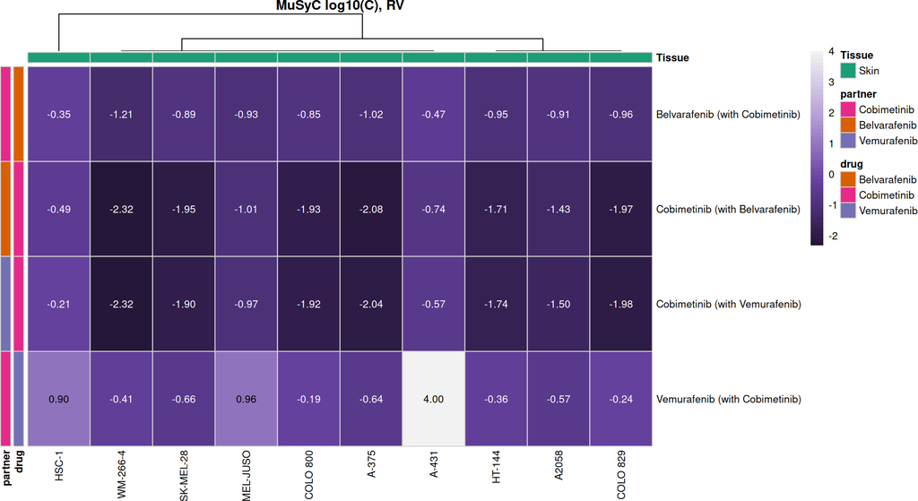

##### 8.2.1.1.3 h

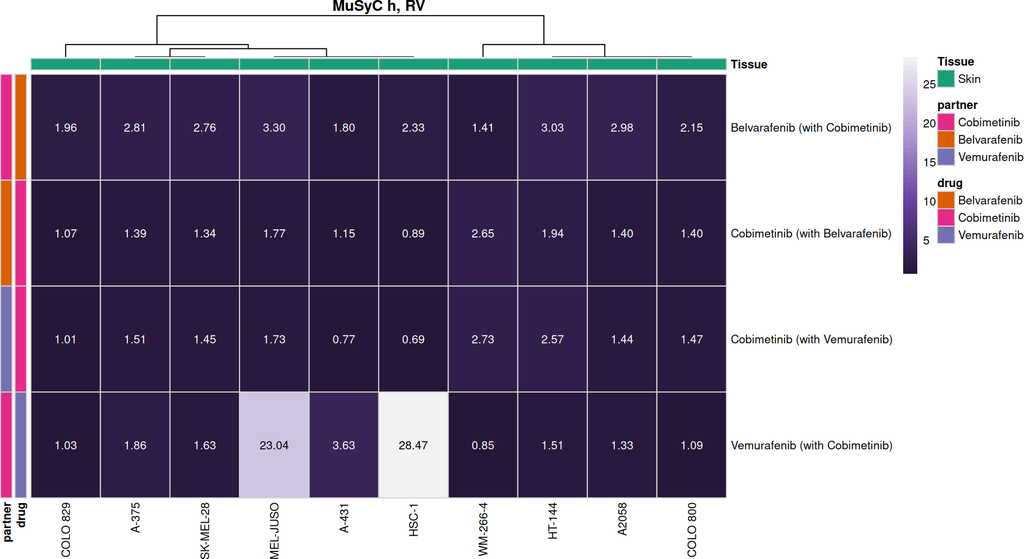

#### 8.2.1.2 GR Value

##### 8.2.1.2.1 E

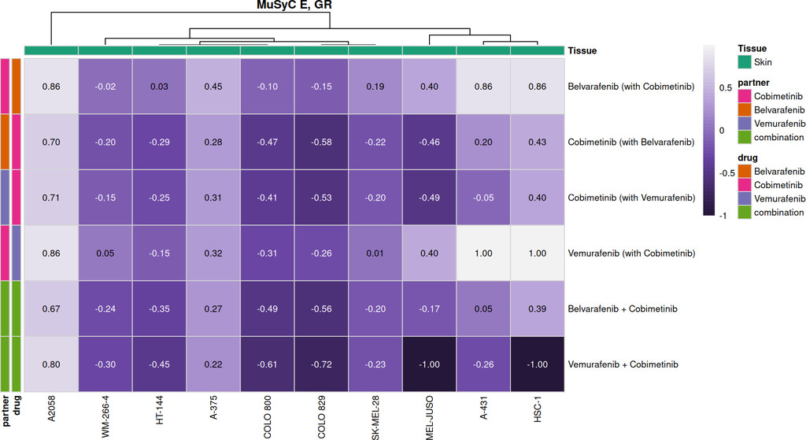

##### 8.2.1.2.2 log10(C)

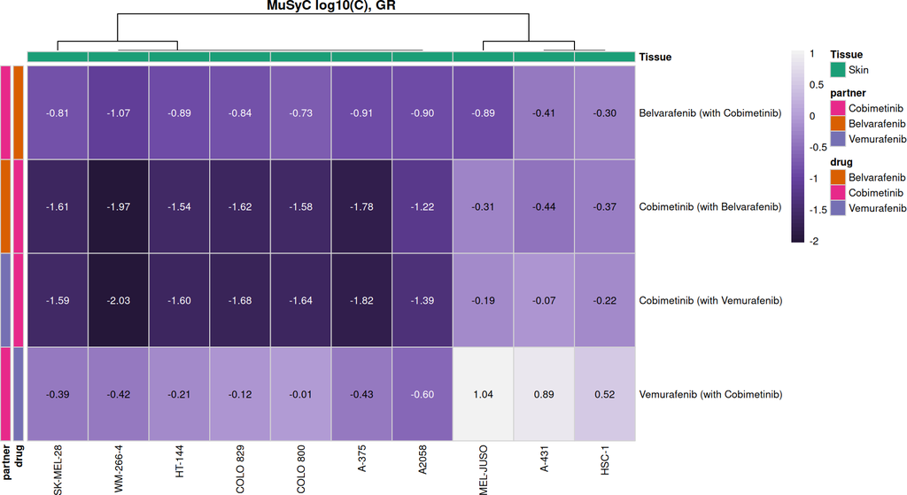

##### 8.2.1.2.3 h

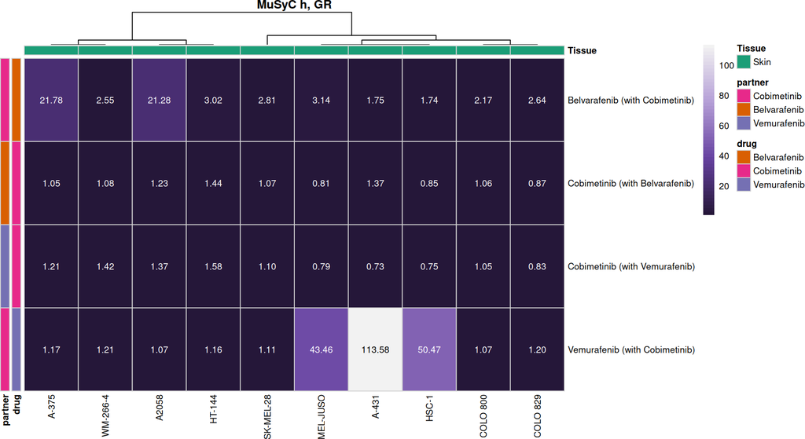

### 8.2.2 Next to the gDR single-agent fit

The single-agent experiment of Step 2 fits each drug on its own. Its `x_inf`, `ec50` and `h` describe the same curve as MuSyC’s `E`, `C` and `h`, so the two fits can be compared drug by drug.

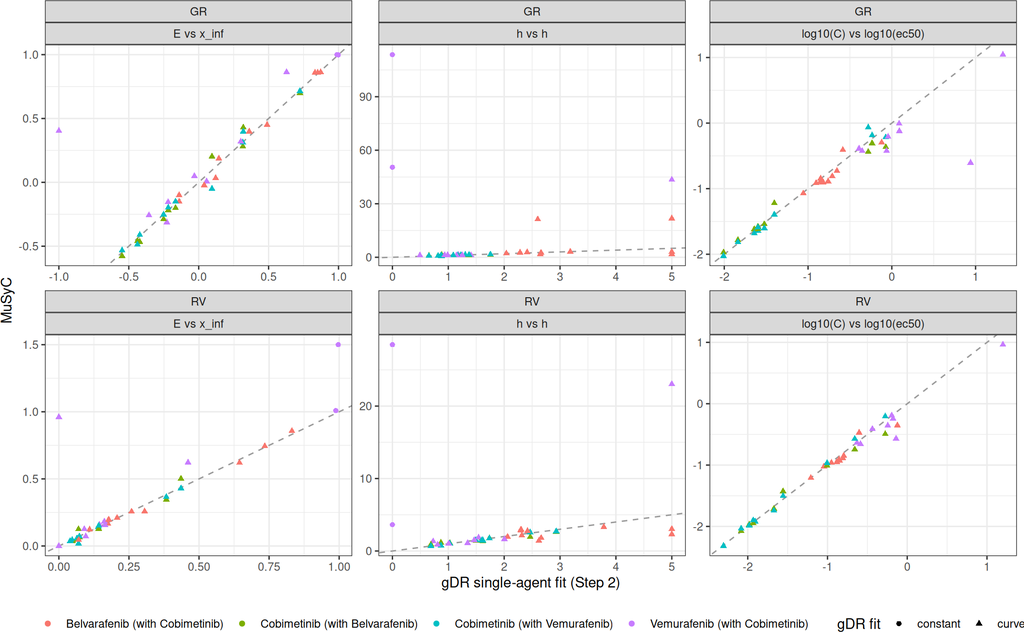

```r
sa_metrics <- convert_se_assay_to_dt(mae[[get_supported_experiments("sa")]], "Metrics")
sa_metrics <- sa_metrics[fit_source == "gDR", c(cell_line_col, drug_col, "normalization_type", "fit_type", "x_inf", "ec50", "h"),
                         with = FALSE]
sa_metrics[, gdr_fit := ifelse(fit_type == "DRCConstantFitResult", "constant", "curve")]
setnames(sa_metrics, c(drug_col, "h"), c("drug", "gdr_h"))
sa_compare <- merge(musyc_drugs[drug != "combination"], sa_metrics,
                    by = c(cell_line_col, "drug", "normalization_type"))
sa_compare <- rbind(
  sa_compare[, .(normalization_type, label = get(drug_col), gdr_fit, parameter = "E vs x_inf", musyc = E, gdr = x_inf)],
  sa_compare[, .(normalization_type, label = get(drug_col), gdr_fit, parameter = "log10(C) vs log10(ec50)",
                 musyc = log10_C, gdr = log10(ec50))],
  sa_compare[, .(normalization_type, label = get(drug_col), gdr_fit, parameter = "h vs h", musyc = h, gdr = gdr_h)]
)
sa_compare <- sa_compare[is.finite(musyc) & is.finite(gdr)]
ggplot(sa_compare, aes(gdr, musyc, colour = label, shape = gdr_fit)) +
  geom_abline(linetype = "dashed", colour = "grey60") +
  geom_point() +
  facet_wrap(normalization_type ~ parameter, scales = "free") +
  labs(x = "gDR single-agent fit (Step 2)", y = "MuSyC", colour = NULL, shape = "gDR fit") +
  theme_bw() +
  theme(legend.position = "bottom")
```

```r
sa_compare[, .(n = .N, spearman = round(stats::cor(musyc, gdr, method = "spearman"), 2)),
           by = .(normalization_type, parameter)]
```

```
##    normalization_type               parameter     n spearman
##                <char>                  <char> <int>    <num>
## 1:                 GR              E vs x_inf    40     0.91
## 2:                 RV              E vs x_inf    40     0.85
## 3:                 GR log10(C) vs log10(ec50)    38     0.95
## 4:                 RV log10(C) vs log10(ec50)    38     0.99
## 5:                 GR                  h vs h    40     0.61
## 6:                 RV                  h vs h    40     0.62
```

## 8.3 Per-combination panels

Step 3 shows each combination as a panel of heatmaps over the dose grid. Here the panel holds the averaged response the fit was given, the MuSyC surface evaluated on the same grid, and their difference. The residual shows where the model misses the data, which `r2` sums up in one number. The measured and fitted heatmaps share one scale.

```r
conc_col <- get_env_identifiers("concentration")
conc2_col <- get_env_identifiers("concentration2")
musyc_surface <- function(grid, fit) {
  predict_musyc_surface(grid[[conc_col]], grid[[conc2_col]], fit)
}
musyc_grid <- merge(avg_dt, musyc_converged[, c(id_cols, "E0", "E1", "E2", "E3", "h1", "h2", "C1", "C2",
                                                "alpha12", "alpha21"), with = FALSE], by = id_cols)
musyc_grid[, measured := x]
musyc_grid[, musyc_fit := musyc_surface(.SD, .SD[1]), by = id_cols]
musyc_grid[, residual := measured - musyc_fit]
```

```r
panel_cells <- unique(musyc_grid[, id_cols, with = FALSE])
setorderv(panel_cells, id_cols)
musyc_panel <- function(cell) {
  dt <- musyc_grid[cell, on = id_cols]
  norm <- cell$normalization_type
  response_limit <- c(min(0, dt$measured, dt$musyc_fit, na.rm = TRUE), max(1, dt$measured, dt$musyc_fit, na.rm = TRUE))
  heatmap_of <- function(metric, title, scale_type, limit = NULL, fill = norm) {
    heatmap_combo_metrics(dt, NULL, cell[[drug_col]], cell[[drug2_col]], cell[[cell_line_col]],
                          metric = metric, normalization_type = norm, scale_type = scale_type, limit = limit) +
      labs(title = title, fill = fill)
  }
  patchwork::wrap_plots(
    heatmap_of("measured", "Measured (Averaged)", "smooth", response_limit),
    heatmap_of("musyc_fit", "MuSyC fit", "smooth", response_limit),
    heatmap_of("residual", "Residual (measured - fit)", "excess", fill = paste(norm, "residual")),
    nrow = 1
  )
}
for (norm in names(norm_names)) {
  cat("\n\n### ", norm_names[[norm]], " {.tabset .tabset-dropdown}\n\n", sep = "")
  cells <- panel_cells[normalization_type == norm]
  plots <- lapply(seq_len(NROW(cells)), function(i) musyc_panel(cells[i]))
  names(plots) <- sprintf("%s (%s x %s)", cells[[cell_line_col]], cells[[drug_col]], cells[[drug2_col]])
  plot_tabs(plots, level = 4)
}
```

### 8.3.1 Relative Viability

#### 8.3.1.1 A-375 (Belvarafenib x Cobimetinib)

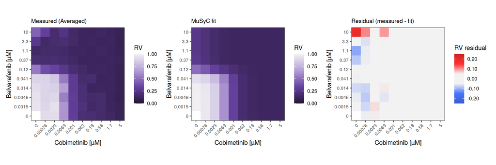

#### 8.3.1.2 A-375 (Vemurafenib x Cobimetinib)

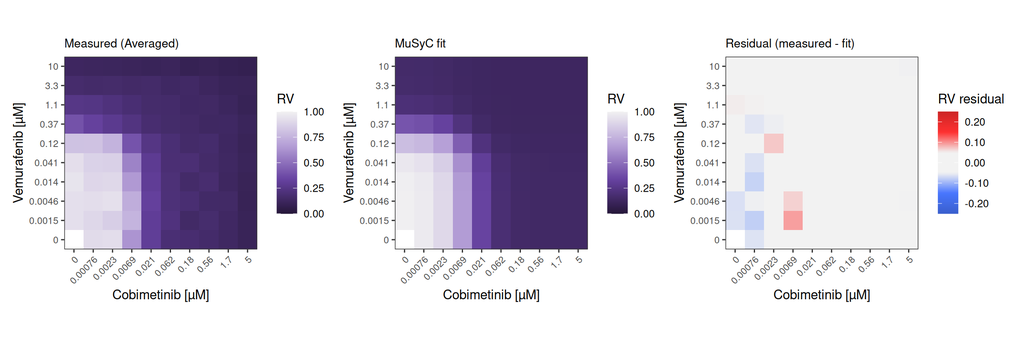

#### 8.3.1.3 A-431 (Belvarafenib x Cobimetinib)

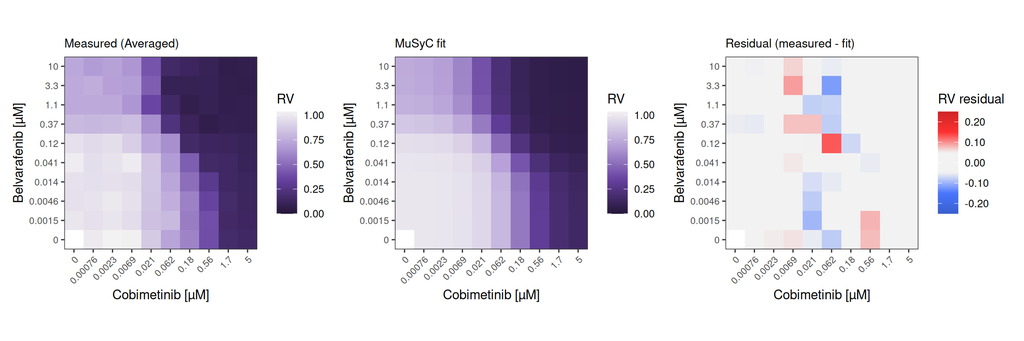